# Omic Browser Data

**Using the MBatch Omic Browser for Data**

**Tod Casasent**

**2021-11-19-0840**

# Introduction

The MBatch Omic Browser contains GDC data converted to Standardized Data format and the results of analysis of that data.

# Standardized Data Format

For a full description of Standardized Data, see the docs at https://github.com/MD-Anderson-Bioinformatics/BatchEffectsPackage/blob/master/docs/MBatch/MBatch_03_StandardizedData.pdf.

In short, Standardized Data has data matrix files and batch or public clinical files. While the basic format is the same, header names and sample ids can vary by project -- we will be discussing the TCGA project here.

Data Matrix Files have a header with a leading tab -- the header is a list of sample ids and the first element of each column is a feature (gene, probe, or similar).

Batch and public clinical files are data frame format tab delimited files. For Batch Files the headers are: Sample, Patient, Type, BatchId, BCR, TSS, PlateId, AliquotCenter, ShipDate, and SourceCenter. The Sample column contains TCGA barcodes for samples. The Patient column contains the first three elements of the TCGA barcode, which identify a patient. Other values are strings or ids for TCGA related information.

For Public Clinical Files the headers are: Patient, days_to_birth, height, weight, race, ethnicity, vital_status, days_to_last_followup, days_to_last_known_alive, days_to_death, relative_family_cancer_history, cancer_first_degree_relative, clinical_stage, pathologic_stage, age_at_initial_pathologic_diagnosis, follow_up_vital_status, follow_up_days_to_last_followup, follow_up_days_to_death, amd follow_up_new_tumor_event_after_initial_treatment. Values may be empty, have the string "null", or NA.

# Finding the Data Archives

The MBatch Omic Browser can be found at https://bioinformatics.mdanderson.org/MQA/. It looks similar to the screenshot below:

[figure not shown]

By default as seen in the lower left of the screen, the TCGA project is selected, with the "current" (as opposed to Legacy) data also selected. The GUI also defaults to showing "Original-Analyzed" data -- this is uncorrected data that has been analyzed using the traditional (called continuous above) algorithms such as PCA+, DSC, Boxplot, and generating several NGCHMs.

Let us assume you are looking for TCGA data for HNSC, LIHC, and PRAD data. In particular you want batch and public clinical data for a variety of sample ids, but are not sure what platform was used.

In the lower left-hand portion of the screen, scroll down to Sub-Project, which for TCGA will have the TCGA disease types. Select the three desired disease types. The list of datasets on the right will update to show just those disease types and the query description will update too. Under Details, we will also select "No Sex Chromosomes" and the empty details checkbox, so we only get Methylation data with sex chromosomes removed but we also get platforms that do not use the sex chromosome option.

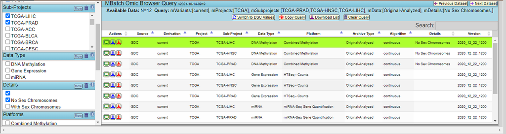

Looking under the Platform column in the list of datasets, you will see we have Combined Methylation (they combined Meth450 and Meth27 into one platform), Gene Expression data in the form of HTSeq Counts, and miRNA as miRNA-Seq Gene Quantification and miRNA-Seq Isoform Quantification.

In each dataset row, clicking the row or the green monitor icon will show the analysis on the top half of the screen. The green highlighted row indicates that dataset is being displayed. Clicking the blue download icon will download the data archive for that dataset. The red download icon will download the analysis results.

Let's download the TCGA-LIHC Methylation data. The archive should end in -data.zip and when you open it look like below. The files at the top level have various information about the download and convert process. The folder named original has the data.

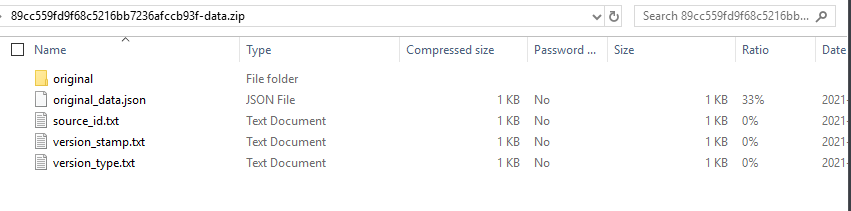

The original folder has the following files. The batches.tsv file is the one we used for processing -- it has empty values for batch values replaced with "Unknown" and samples not in the dataset removed. This version of the code puts the unchanged batch information into batches.tsv.bak. The current version names the file original-batches.tsv. Since you can see the edited file is smaller extract the batches.tsv.bak file, in case the samples you want have been removed.

The public clinical data is in clinical.tsv. It is not currently used in our pipeline, so there is no edited version. Future versions will add the public clinical data as annotation bars into Hierarchical Clustering and the NGCHMs generated.

Note that matrix_data.tsv also has a bak version. Looking at the files, you will see they are identical -- check the content as well as the size. Current versions of the software use the original-matrix_data.tsv instead of bak.

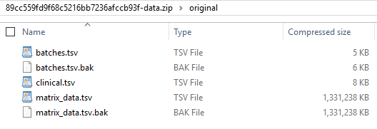

If instead you had downloaded the HTSeq Counts data archive, the matrix_data.tsv and bak file would be different sizes. Looking at the data, you would see the matrix_data.tsv was log transformed in the manner described in the Standardized Data documentation.

# Sample Batch Data

Using the batches.tsv.bak file, load it into R. The MBatch R package provides a convenience function shown below for this. Notice the many arguments passed to read.csv to prevent it changing the strings in the data file.

> readAsGenericDataframe <- function(theFile, theNaString=NULL, theUnknownString="Unknown")

> {

> df <- read.csv(theFile, header=TRUE, sep="\t", as.is=TRUE, check.names=FALSE,

> stringsAsFactors=FALSE, colClasses="character", na.strings=theNaString,

> allowEscapes=TRUE)

> df[df==""] <- theUnknownString

> return(df)

> }

You can then use the Sample column to select the batch information you want.

# Patient Public Clinical Data

Using the clinical.tsv file, load it into R using the same function used above. You can then convert barcodes to patient ids using:

patientIds <- substr(theBarcodes, 1, 12)

You can then use the Patient column to select the public clinical information you want.

# Automatically "Corrected" Data

Datasets in the MBatch Omic Browser, with Archive Type Adjusted-EB_withPara, have been corrected using an automated system without human input. The correction does not imply the presence or absence of batch effects in the original data. The user is solely responsible for assessing batch effects (e.g. by using our assessment tools) and deciding whether or not to use the corrected data, which may or may not have mitigated some useful biological information along with any technical artifacts.

Using a similar process to Finding the Data Archives, we download the results using the red Download Results Archive button.

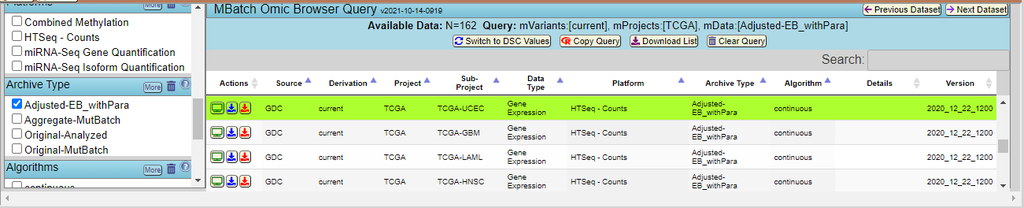

The archive ZIP has the following files:

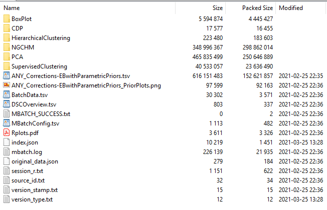

The directories contain output of the analysis algorithms, both data files used by the MBatch Omic Browser and basic PNG visualization files. Most of the files are information from the processing, many of which are described earlier.

The Any_Corrections-EBwithParametricPriors.tsv file contains the auto-corrected matrix file -- this has the same format as the Standardized Data matrix file described earlier. If other correction algorithms are used, the last part of the filename will have that method's name.

The BatchData.tsv file has a simplified version of the previously described batch information files. This one has the sample ids and the three batch types which were part of the processing.